## Some first notes

Welcome to the quantiNEMO tutorial series. quantiNEMO is a software that allows you to simulate populations of individuals with genotypes, phenotypes, migration, selection and much more. It is an incredibly exhaustive software that allows the simulation of an extreme diverse array of biological scenarios, both forwards and backwards in time (see the different vignettes on this website for some examples). However, the basics of quantiNEMO are very simple. The following four tutorials will demonstrate the some of the functionality of quantiNEMO, giving you the basic skills that will allow you to later build your own more complex scenarios. Though the manual provides all information you would need to successfully use quantiNEMO, you will not need to read it yet. These tutorials will give you a head start. You will see that throughout these tutorials we do refer so specific sections in the manual if you would like to know more about certain functionality of the quantiNEMO software. During the tutorial, quantiNEMO will often be abbreviated as ‘qN’. Moreover, the produced files will often have names that are different from the ones within this tutorial (because they have names with dates etc.). Therefore, we will often simply refer to the variable part of a name as ‘xxx’ (e.g. xxx.txt).  
This tutorial was written to work with quantiNEMO version 2.0. Though most of the tutorial should work fine under other versions, it might differ in some, important, details such as parameter encoding.  
We recommend you not to copy-past sample code from this tutorial into a setup file, since this can often introduce ‘hidden’ errors, but instead retype the text (the mastering of any art starts by copying it). However, all setup files (files ending with .ini) described and used during these tutorials can be downloaded from this website directly . Furthermore, many of the visualisations and analyses after the simulations have been performed in the statistical software package R. Though some of the first plotting exercises can be performed in Excel, data manipulations later in this tutorial require the aid of the more flexible environment of R. Because the scope here is not to explain the workings of R (there are excellent online tutorials for those), we do go into too much detail and instead provide readymade R-scripts here . However, we recommend those who do know R to first try reading and analysing the data yourself.

### 0 Getting started

QuantiNEMO is freely distributed and can be easily downloaded from the internet, for example here . Several versions exists, including the source code, but we need an executable version. Make sure you download the version suitable for your operating system (Linux, Mac or Windows). After downloading, see the section corresponding to your operating system for your first instructions.

#### 0. 1 Basic usage on a Windows machine

The file you downloaded is still compressed as a zip-file. Unzip it to a location where you would like qN to run. Inside the folder, you will find three items: the manual (a pdf-file), the application (or ‘executable’ ending on .exe), and a setup file named ‘quanitNemo.ini’. N.B. It may be that your version of windows does not show the extension (.exe .pdf) of all items. If you want to change that, got to Control Panel > Appearance and Personalization > Folder Options; go to the ‘View’ tab; under ‘Advanced settings’ untick ‘Hide extensions for known file types’ and click OK. This tutorial will often refer to certain sections in the manual so it will be good to keep at hand. The executable is the actual program. Double click it. A black command prompt window will have opened which shows some text on screen including with on the bottom ‘replicate 1/1’ with a timer and a fraction of hundred counting up (see figure below). image:

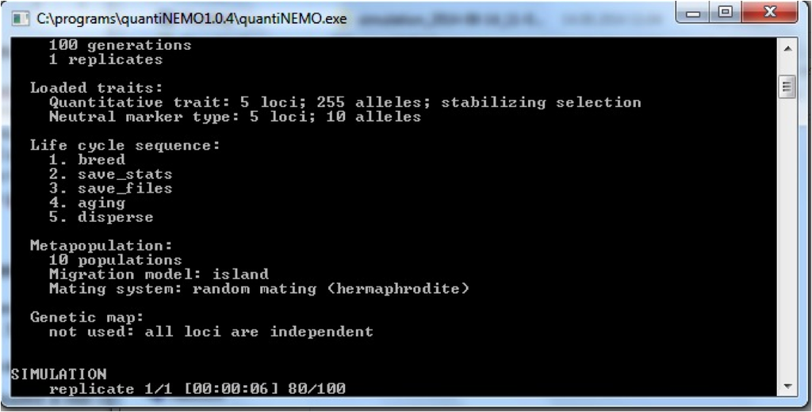

Once the counter reaches 100, the window will disappear again. The simulation has functioned perfectly, but at times the immediate disappearance of the prompt can be inconvenient when you want to read e.g. error messages. There is a trick to keep the prompt open by not launching quantiNemo.exe directly, but via the command prompt: Right-click in the folder with the qN executable (but on an icon), go to New > Shortcut. Type instead of a file path “cmd.exe”, click ‘Next’ and then ‘Finish’. A new short has appeared in your folder. Right-click this shortcut and go to ‘Properties’. In the Properties window, change the ‘Start in’ path to the path where your current folder with the qN-files reside and click OK. image:

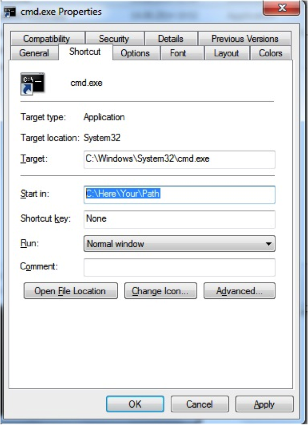

When you now click the cmd.exe shortcut, a command prompt opens with as a top line the path of your current folder (the qN folder). If you want to launch qN just type quantiNemo.exe image:

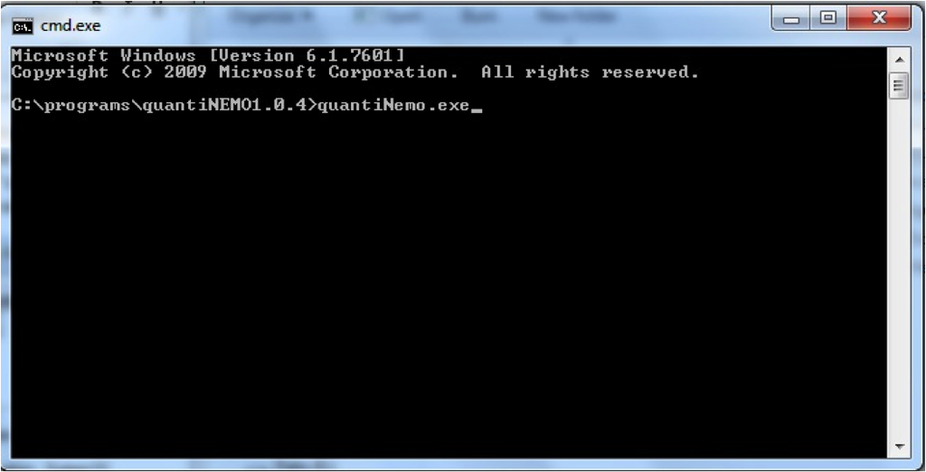

When you press enter, qN will launch itself again, just as before. The big difference, however, is that the prompt stays open after finishing! You may have noticed that while running qN twice, two new folders have appeared within the qN folder, both whose names start with ‘simulation_’… You may delete these two folders for now. Lastly, when you launch qN, it will automatically look for the setup file named ‘quantiNemo.ini’. We do not want this to happen during our tutorials. Therfore, as a last preparation before getting started, rename the ‘quantiNemo.ini’ file (e.g. as ‘quantiNemoExample.ini’).

#### 0.2 Basic usage on a MAC

Drag and extract the downloaded ‘quantinemo_mac.zip’ file to a location where you would like qN to run. Inside your qN folder, you will find three items: the manual (the pdf-file), a setup file named ‘quanitNemo.ini’ and the application (or executable) itself, with no extension. This tutorial will often refer to certain sections in the manual so it will be good to keep it at hand. The setup file we will ignore for the moment. The executable ‘quanitNemo’ is the actual program. To launch it double click the executable or launch it within a terminal session by executing the following command: ./quantiNemo.

#### 0.3 Basic usage in Linux

Drag and extract the downloaded ‘quantinemo_linux.zip’ file to a location where you would like qN to run. Inside your qN folder, you will find three items: the manual (the pdf-file), a setup file named ‘quanitNemo.ini’ and the application (or executable) itself, with no extension. This tutorial will often refer to certain sections in the manual so it will be good to keep it at hand. The setup file we will ignore for the moment. The executable ‘quanitNemo’ is the actual program. To launch it double click the executable or launch it within a terminal session by executing the following command: ./quantiNemo.

### 1 Demographics

This first tutorial/vignette will show the basic population dynamics as they happen in quantiNEMO (qN).

#### 1. 1 A first simulation of a growing population

Let’s start with a basic setup file. Open notepad (or your personal favourite plain text editor) and type the text below into it (copying it directly can often give silly errors):

> # A simple illustration of demography in quantiNEMO generations 20  
> patch_capacity 1000  
> patch_ini_size 4  
> mating_nb_offspring_model 3 # 3 = fecundity  
> mean_fecundity 1.5  
> regulation_model_adults 1 # 1 = yes; 0 = no (default)  
> stat {adlt.nbInd}

Type Demo1.ini (or the name you gave your setup-file, including any extensions) and press enter. The simulation will run now and should take less than a second. N.B. Make sure your file is not saved as “Demo1.ini.txt”; some text editors will automatically add the ‘.txt’ extension if not told otherwise. N.B. If qN does not ask you to enter the settings file name, but immediately starts the simulation, it is because you still have a file in your qN folder named ‘quantiNemo.ini’, which qN automatically runs. To prevent this from happening, rename this file. At the end of the simulation a new folder should have appeared in the folder containing qN carrying the same name as the setup file (in our case ‘Demo1’) followed by the date and time you started the simulation. In this folder you will find five files. Open simulation_stats.txt and ignore the other files for the moment. The top of the file will look like this:

| replicate | generation | adlt.nbInd |
| --- | --- | --- |
| 1 | 1 | 4 |
| 1 | 2 | 6 |
| 1 | 3 | 9 |
| 1 | 4 | 14 |
| 1 | 5 | 21 |
| 1 | 6 | 32 |
| 1 | 7 | 48 |
| 1 | 8 | 72 |
| 1 | 9 | 108 |
| 1 | 10 | 162 |
| 1 | 11 | 243 |
| 1 | 12 | 365 |
| 1 | 13 | 548 |
| 1 | 14 | 822 |
| 1 | 15 | 1000 |

Question: What parameter did we use to prevent our population to grow to 1.7 billion individuals?

Question: Would there be another way of obtaining the same results as above in qN without using this parameter? (Have a look in the manual at the mating_nb_offspring_model options.)

#### 1.2 A second growth model

> # A simple illustration of logistic growth in quantiNEMO generations 20 patch_capacity 1000 patch_ini_size 4 mating_nb_offspring_model 6 # 6 = logistic regulation growth_rate 1.5 stat {adlt.nbInd fem.meanFec}

Resave this file as Demo2.ini and run it in qN. Again a new ‘Demo2__’ folder appears. The simulation_stats.txt file within contains a fourth column which specifies the female fecundity. Each statistic you add in the {} behind stat will appear as a column in the simulation_stat.txt file (do not use commas to separate these terms!). Unlike our previous simulation, where we fixed the female fecundity, here the fecundity is dependent on the population size. So in the beginning, when the population is small, we see very high fecundity. In the end fecundity drops to 2, just enough to keep the population at level. (Each hermaphrodite ‘female’ gives birth to 1 offspring, but each of them also fathers a second offspring with one of the other hermaphrodite ‘females’, therefore total fecundity of each ‘female’ equals two!). Using software like R we can visualize the growth curves from section 1.1 and 1.2. (The needed r-script is included, but you can also use Excel for this particular exercise.)

Here we clearly see the difference in behaviour between mating_nb_offspring_model at what time carrying capacity is reached: when growth is determined by female fecundity (as in section 1.1), growth is exponential until it is ruthlessly cut-off once it reaches 1000 individuals. When growth is determined by logistic regulation (this section), the population shows density dependent growth: fast when few individuals are around, but gently slowing down as it approaches carrying capacity.

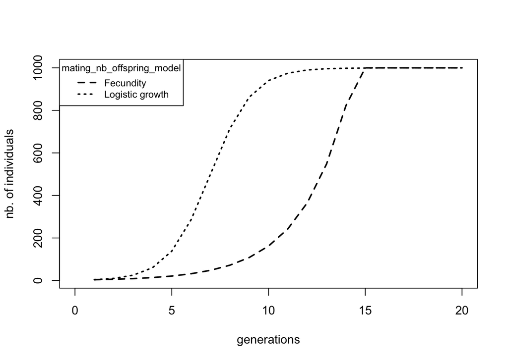

```r
    # Select the simulation_stats.txt file from Demo1 (the fecundity simulation)
    demo1<-read.table("demography/exponential/simulation_stats.txt", header=T)
    # Select the simulation_stats.txt file from Demo2 (the logistic growth simulation)
    demo2<-read.table("demography/logistic/simulation_stats.txt", header=T)
    # plotting the data
    plot(demo1$generation,demo1$adlt.nbInd, xlim=c(0,20), xlab="generations",ylab="nb. of individuals", type='l', lty=2, lwd=2)
    lines(demo2$generation,demo2$adlt.nbInd, pch=2, lty=3, lwd=2)
    legend("topleft", c("Fecundity", "Logistic growth"), lty=c(2,3), lwd=2, cex=0.8, title="mating_nb_offspring_model")
```

Question: Above we plotted the number of individuals over time. How would the fecundity over time look for the two different scenarios? Produce this plot.